# Hurricane Analysis (Working Title)

Author

Logan MacFarlane and Lorenzo D. Moon

Published

November 30, 2025

## General Background

This dataset provides a comprehensive historical background on tropical cyclones, including hurricanes and typhoons, spanning from 1970 to 2024. It consists of detailed observations that allow for tracking the complete life cycle of individual storms, capturing their paths and changes in intensity over time. Key information recorded for each storm includes its name, a unique identifier, its precise geographical coordinates, the ocean basin of its activity, and critical intensity metrics such as maximum sustained wind speed and minimum central atmospheric pressure.

## Variable Descriptions

| Variable | Data Type | Description |
| --- | --- | --- |
| object_id | int64 | Primary Key for each storm |
| sid | string | Storm identifier |
| basin | string | Ocean basin where the storm occurred |
| sub_basin | string | Sub-basin within the ocean basin |
| name | string | Name of the storm |
| nature | string | Nature/type of the storm |
| year | int64 | Year of the observation (EST) |
| month | int64 | Month of the observation (EST) |
| day | int64 | Day of the observation (EST) |
| date | string | Date of the observation (GMT/ZULU) |
| latitude | float64 | Latitude of the storm’s location |
| longitude | float64 | Longitude of the storm’s location |
| usa_wind | int64 | Maximum sustained wind speed (in whole knots) |
| usa_pres | int64 | Minimum central atmospheric pressure (in mb) |

### Basin Codes

| Code | Description |
| --- | --- |
| SI | South Indian |
| SP | South Pacific |
| WP | Western Pacific |
| NI | North Indian |
| NAB | North Atlantic Basin |
| EP | Eastern Pacific |
| SA | South Atlantic |

### Sub-Basin Codes

| Code | Description |
| --- | --- |
| MM | Malay Archipelago |
| WA | Western Australia |
| EA | Eastern Australia |
| BB | Bay of Bengal |
| CS | Caribbean Sea |
| GM | Gulf of America Mexico |
| NAB | North Atlantic Basin |
| AS | Arabian Sea |
| CP | Central Pacific |

### Nature Variable Codes

| Code | Description |
| --- | --- |
| TS | Tropical Storm |
| NR | Not Rated |
| MX | Maximum Intensity |
| ET | Extratropical |
| DS | Dissipating |
| SS | Subtropical Storm |

## Research Questions

**1) Are the most extreme storms (top 10% in a given year) becoming more intense over time?**

**Hypotheses:**

- **$H_0$**: No increase in intensity of the most extreme storms over time.
- **$H_a1$**: The intensity of the most extreme storms is increasing over time.
- **$H_a2$**: The intensity of the most extreme storms is decreasing over time.

**2) Do the various ocean basins exhibit statistically significant differences in the rate of increase of tropical cyclone frequency?**

**Hypotheses:**

- **$H_0$**: No difference in the rate of increase of tropical cyclone frequency among ocean basins.
- **$H_a$**: At least one ocean basin has a different rate of increase in tropical cyclone frequency compared to others.

## Question 1 Analysis

### Figures and Results

```
The Shapiro-Wilk test shows the data is normally distributed, with p-value = 0.18447249959037681
Pearson Correlation shows the data has a positive correlation of 0.6541434640926322 with p-value = 6.09553231277667e-08
There is a statistically significant correlation between year and average intensity of extreme storms.
```

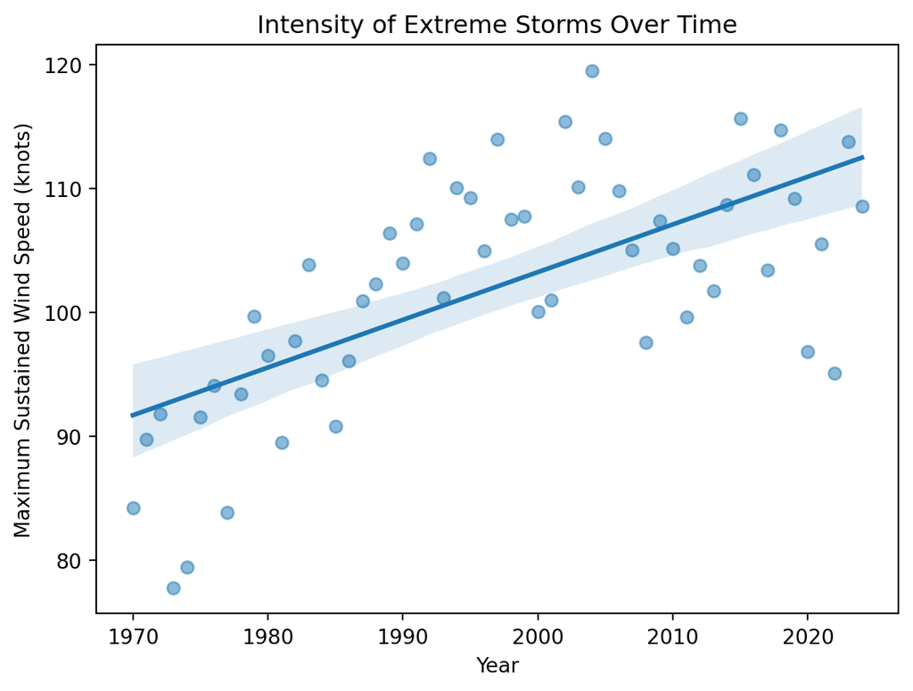

```
Rate of increase in intensity of extreme storms: 0.3853 knots per year
```

Based on the statistical analysis, the data appears to be normally distributed, as indicated by the Shapiro-Wilk test yielding a high p-value of approximately 0.184. The Pearson correlation analysis further reveals a statistically significant positive correlation between the year and the average intensity of extreme storms, with a correlation coefficient of approximately 0.654 and an extremely low p-value. This strong p-value definitively supports the conclusion that the observed positive relationship is highly unlikely to be due to random chance.

## Question 2 Analysis

### Figures and Results

```
Shapiro-Wilk Test for EP: Statistics=0.9724055503504704, p-value=0.23556716887953588
The data for EP is normally distributed, with p-value = 0.23556716887953588
Shapiro-Wilk Test for NAB: Statistics=0.9797097177037554, p-value=0.4755874198127482
The data for NAB is normally distributed, with p-value = 0.4755874198127482
Shapiro-Wilk Test for NI: Statistics=0.9398867787493596, p-value=0.00841395797637418
The data for NI is not normally distributed, with p-value = 0.00841395797637418
Shapiro-Wilk Test for SA: Statistics=0.23739257494417254, p-value=2.2741753450750044e-15
The data for SA is not normally distributed, with p-value = 2.2741753450750044e-15
Shapiro-Wilk Test for SI: Statistics=0.9330483292397125, p-value=0.004377097084201904
The data for SI is not normally distributed, with p-value = 0.004377097084201904
Shapiro-Wilk Test for SP: Statistics=0.9021698968915994, p-value=0.00029642158482800444
The data for SP is not normally distributed, with p-value = 0.00029642158482800444
Shapiro-Wilk Test for WP: Statistics=0.9734747896322092, p-value=0.2624265245405758
The data for WP is normally distributed, with p-value = 0.2624265245405758
Rate of increase for EP: 5.121717171717172 storms per year
Rate of increase for NAB: 7.995093795093795 storms per year
Rate of increase for NI: -2.1743145743145753 storms per year
Rate of increase for SA: 0.10331890331890334 storms per year
Rate of increase for SI: -8.224675324675326 storms per year
Rate of increase for SP: -9.362193362193365 storms per year
Rate of increase for WP: -19.498124098124105 storms per year
```

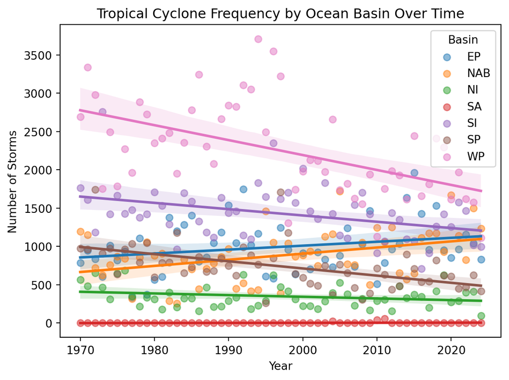

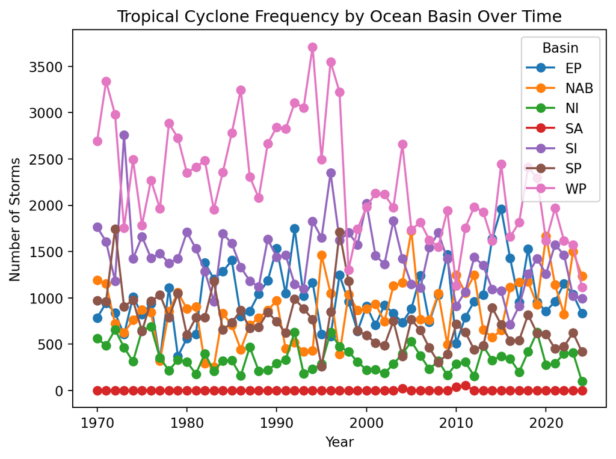

## Machine Learning Model

```
Model Coefficients:
year         4.157971e-01
basin_NAB   -6.965130e-01
basin_NI     3.113784e-01
basin_SA    -4.718448e-16
basin_SI     1.172803e+00
basin_SP     1.922008e+00
basin_WP     5.574676e+00
dtype: float64
R-squared: 0.1334
Predicted intensity for year 1988 in basin NAB: 95.29 knots
```

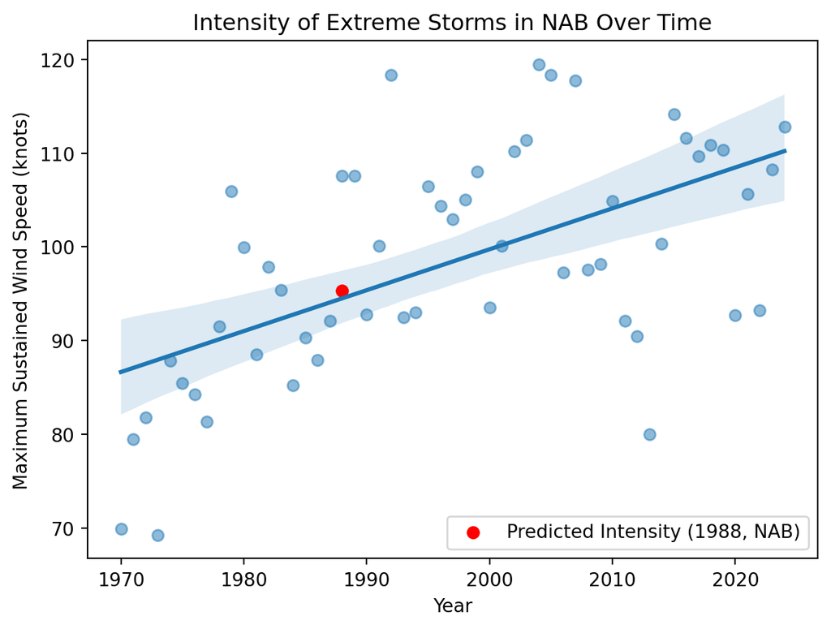

## Conclusions

Based on the statistical and machine learning analyses conducted on historical tropical cyclone data from 1970 to 2024, the following conclusions can be drawn regarding the intensity of extreme storms and the frequency of tropical cyclones across various ocean basins.

**1. Intensity of Extreme Storms**

The analysis for Research Question 1: Are the most extreme storms (top 10% in a given year) becoming more intense over time?

Definitively supports the alternative hypothesis that the intensity of the most extreme storms is increasing over time.

Statistical Significance: The Pearson correlation analysis showed a statistically significant positive correlation between the year and the average intensity of extreme storms, with a correlation coefficient of approximately 0.654 and an extremely low p-value. This p-value indicates the positive relationship is highly unlikely to be due to random chance.

Data Distribution: The data for this analysis appears to be normally distributed, supported by a Shapiro-Wilk test p-value of approximately 0.184.

Rate of Increase: The rate of increase in intensity for extreme storms is calculated to be 0.3853 knots per year.

**2. Storm Frequency by Ocean Basin**

The analysis for Research Question 2: Do the various ocean basins exhibit statistically significant differences in the rate of increase of tropical cyclone frequency?

Eastern Pacific (EP): 5.1217 storms per year

North Atlantic Basin (NAB): 7.9951 storms per year

North Indian (NI): -2.1743 storms per year

South Indian (SI): -8.2247 storms per year

South Pacific (SP): -9.3622 storms per year

Western Pacific (WP): -19.4981 storms per year

Distribution: While some basins’ data (EP, NAB, WP) were found to be normally distributed based on the Shapiro-Wilk test, the data for others (NI, SA, SI, SP) were determined to be not normally distributed.

**3. Machine Learning Prediction**

A machine learning model was used to predict the intensity of extreme storms, yielding an R-squared value of 0.1334.

Prediction: The model predicted the intensity for an extreme storm in the North Atlantic Basin (NAB) in the year 1988 to be 95.29 knots.